# Open data survey

# Question 32

**Would you like more guidance on how to comply with the policies of any of the below on making your research data openly available?**

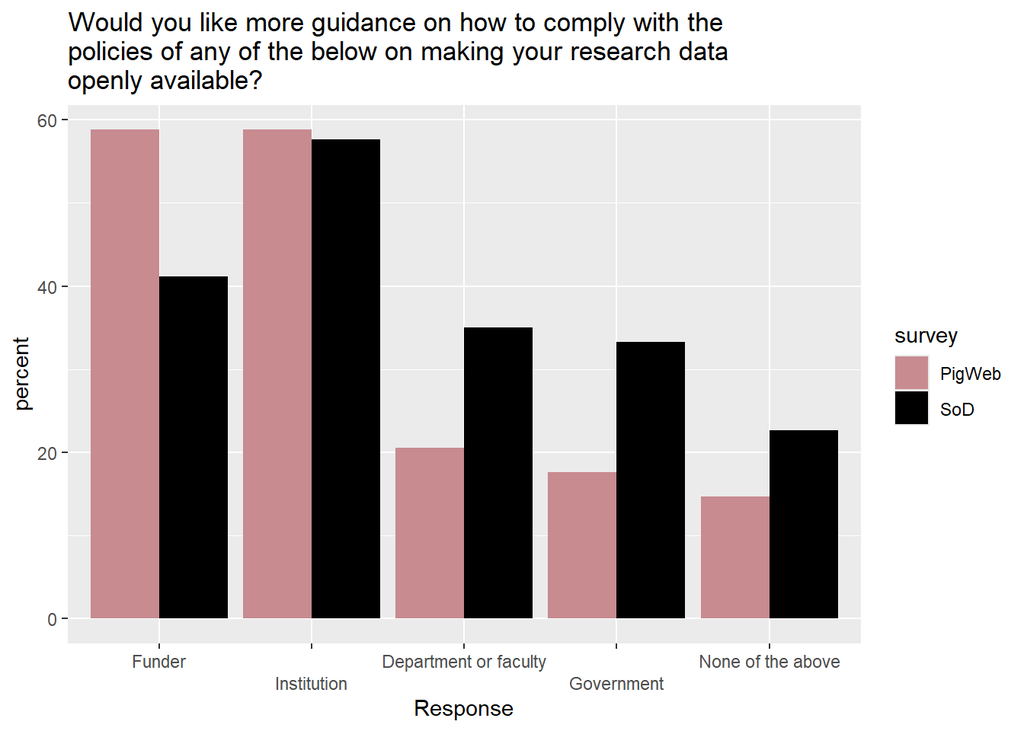

Figure 32

```r
# Answered by Yishu

#This code chunk uses the multiple choice functions.
Q32_levels = c("Funder",
              "Institution",
              "Department or faculty",
              "Government",
              "None of the above")
n_columns = length(Q32_levels)

# Double check that the columns correspond to the right question:
# colnames(sod21)[96]
# colnames(pigw21)[76]

sod21Q32 = as.data.frame(dplyr::select(sod21, (96:sum(96,n_columns,-1))))
sod21Pile = cbind(sod21Pile, sod21Q32)

pigw21Q32 = as.data.frame(dplyr::select(pigw21, (76:sum(76,n_columns-1))))
pigw21Pile = cbind(pigw21Pile, pigw21Q32)

Q32 = 'Would you like more guidance on how to comply with the policies of any of the below on making your research data openly available?'

Q32_data = format_question_multiple_choice(sod21Q32,
                                          pigw21Q32,
                                          Q32_levels)

plot_multiple_choice(Q32_data,
                     Q32_levels,
                     Q32,
                     "Response")
```

# Question 33

**How would you rate the importance of the following with reference to determining the quality of an openly accessible data set? The data are available from a publicly available repository.**

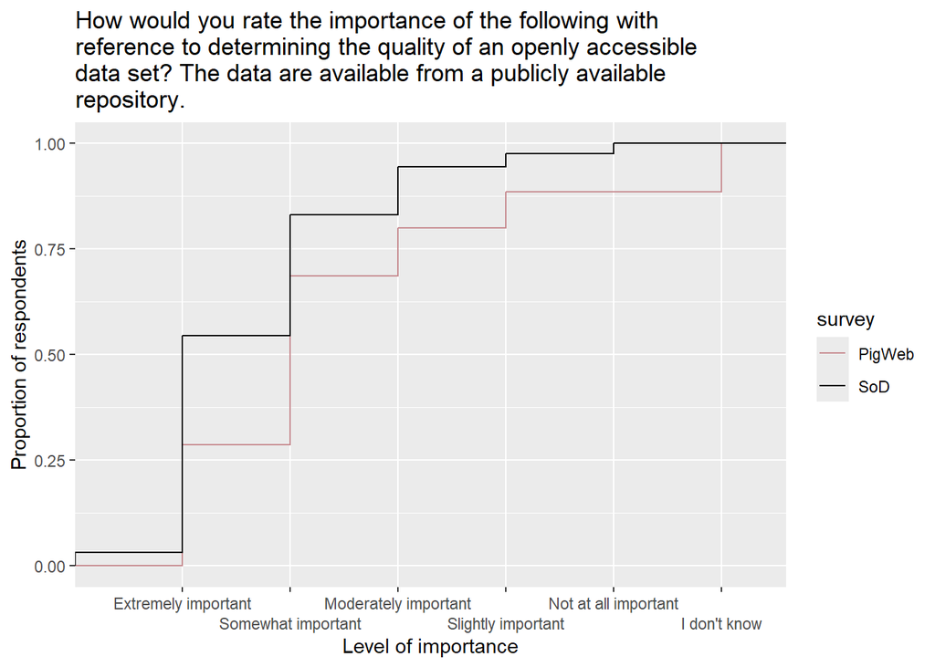

Figure 33

```r
# Answered by Yishu

#This code chunk uses the likert scale functions.

# Double check that the columns correspond to the right question:
# colnames(sod21)[127]
# colnames(pigw21)[124]

#Creating data sets for Q33 (In otherwords: Isolating the responses of Q33 in the two surveys and adding this to a compiled data set, one for each survey)
sod21Q33 = as.data.frame(dplyr::select(sod21,127))
sod21Pile = cbind(sod21Pile, sod21Q33)

pigw21Q33 = as.data.frame(dplyr::select(pigw21, 124))
pigw21Pile = cbind(pigw21Pile, pigw21Q33)


#Setting columnnames and storing the question for Q33
colnames(sod21Q33) = c('Q33')
colnames(pigw21Q33) = c('Q33')
Q33 = 'How would you rate the importance of the following with reference to determining the quality of an openly accessible data set? The data are available from a publicly available repository.'

#Setting the answer options to Q33.
Q33_levels = c("Extremely important", "Somewhat important",
               "Moderately important", "Slightly important",
               "Not at all important", "I don't know")

#The Pigweb scale is correctly formatted for this question (Q33), thus no need to reverse the question.
#pigw21Q33$Q33 = reverseCode(pigw21Q33$Q33)

Q33_data = format_question_likert(sod21Q33$Q33, #Making the answers to Q33 in the two questionnaires comparable, merging them to one data frame
                                  pigw21Q33$Q33,
                                  Q33_levels)

plot_likert(Q33_data,  #Plotting the Level of importance
            Q33_levels,
            Q33,
            "Level of importance")
```

```r
#This section test for if there is statistically significant difference in the respondent groups¨
#with the null hyptohesis that the two populations are the same.

SvPQ33 = ks.test(Q33_data$response[Q33_data$survey == "SoD"],
                 Q33_data$response[Q33_data$survey == "PigWeb"],
                 ifresult = FALSE) #Kolmogorov-Smirnov test for Q33
SvPQ33
```

```
##
##  Asymptotic two-sample Kolmogorov-Smirnov test
##
## data:  Q33_data$response[Q33_data$survey == "SoD"] and Q33_data$response[Q33_data$survey == "PigWeb"]
## D = 0.26, p-value = 0.02
## alternative hypothesis: two-sided
```

# Question 32

> **Since January 2020, have you reused any of the below as part of your research?**

> Please select all that apply:
> - Your own data
> - Openly accessible data shared by other research groups
> - Neither of the above

> [**Note**: by ‘reuse’ we mean undertaking new analysis of a pre-existing data set, either on its own or to add to another data set, to answer a different research question to that which the collection of data was originally intended]

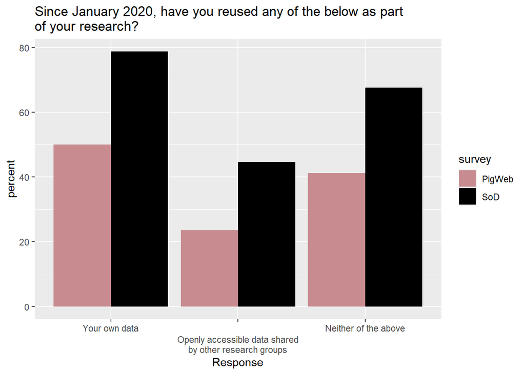

Figure 32.1

```r
# Answered by Lina

# This is a multiple-choice question stored as one indicator column per response option.

# Checking that index corresponds to right question
# colnames(sod21)[101:103]
# colnames(pigw21)[115:117]

# Giving the answer options to Question 32 - the ticks on the x axis when plotting
Q32.1_levels = c("Your own data",
              "Openly accessible data shared by other research groups",
              "Neither of the above")

# Create data frames of answers from both surveys - by extracting the multiple columns of the respective data frame that contains the answers
pigw21Q32.1 <- as.data.frame(dplyr::select(pigw21, 115:117))
sod21Q32.1 = as.data.frame(dplyr::select(sod21, 101:103))

# Checking if there are any individuals with no answer to the question - if either is TRUE add a "no answer" level
# all(rowSums(is.na(pigw21Q32.1)) == ncol(pigw21Q32.1))
# all(rowSums(sod21Q32.1 == 0) == ncol(sod21Q32.1))

# Storing the question - later used to give our plot a title
Q32.1 <- 'Since January 2020, have you reused any of the below as part of your research?'

# Creating a data frame containing percentages for each option for plotting multiple-choice questions: arguments in this order:
# 1. sod_data (represent columns with each available answers)
# 2. pigweb_data (represent columns with each available answers)
# 3. levels is a vector of the options
Q32.1_data <- format_question_multiple_choice(sod21Q32.1,
                                          pigw21Q32.1,
                                          Q32.1_levels)

# Plotting a bar chart of percentages for a multiple choice questions: arguments in this order:
# 1. Data frame produced by format_question_multiple_choice
# 2. Vector of the answer options
# 3. Character string of plot title - Q32 question
# 4. Character string for the x-axis label (not a separate vector, write text below)
plot_multiple_choice(Q32.1_data,
                     Q32.1_levels,
                     Q32.1,
                     "Response")
```

# Question 33

> **How do you think the data shared by others has or could benefit you?**

> Please select all that apply:
> - Fosters collaboration
> - Validates findings
> - Complements data
> - Avoids duplication
> - No benefit
> - Other (please specify)

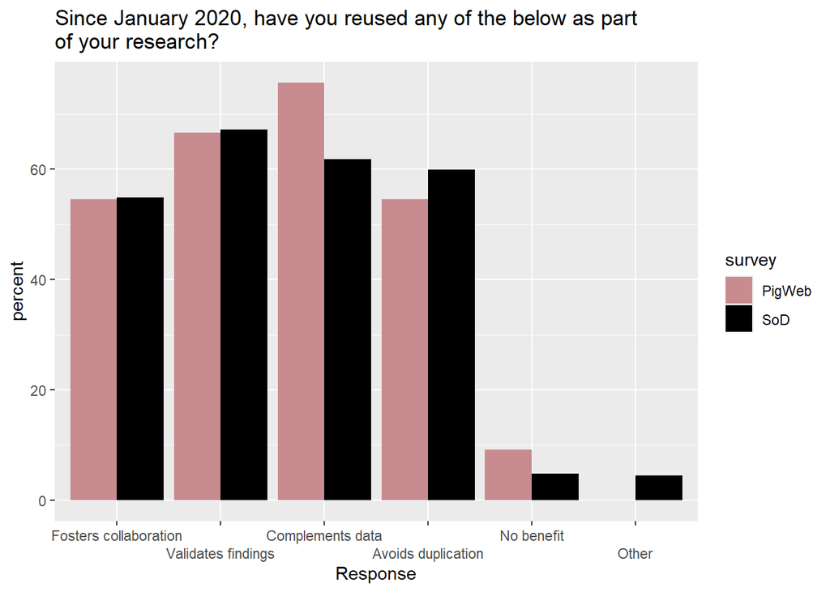

Figure 33.1

```r
# Answered by Lina

# This is a multiple-choice question stored as one indicator column per response option.

#Checking that index corresponds to right question
# colnames(sod21)[106:112]
# colnames(pigw21)[118:124]

# Giving the answer options to Question 33 - the ticks on the x axis when plotting
Q33.1_levels = c("Fosters collaboration", "Validates findings", "Complements data", "Avoids duplication", "No benefit", "Other")

# Create data frames of answers from both surveys - by extracting the multiple columns of the respective data frame that contains the answers

pigw21Q33.1 <- as.data.frame(dplyr::select(pigw21, 118:123))
sod21Q33.1 = as.data.frame(dplyr::select(sod21, 106:109,111,110))

# Checking if there are any individuals with no answer to the question - if either is TRUE add a "no answer" level
# all(rowSums(is.na(pigw21Q33.1)) == ncol(pigw21Q33.1))
# all(rowSums(sod21Q33.1 == 0) == ncol(sod21Q33.1))

# Storing the question - later used to give our plot a title
Q33.1 <- 'Since January 2020, have you reused any of the below as part of your research?'

# Creating a data frame containing percentages for each option for plotting multiple-choice questions: arguments in this order:
# 1. sod_data (represent columns with each available answers)
# 2. pigweb_data (represent columns with each available answers)
# 3. levels is a vector of the options
Q33.1_data <- format_question_multiple_choice(sod21Q33.1, pigw21Q33.1, Q33.1_levels)

# Plotting a bar chart of percentages for a multiple choice questions: arguments in this order:
# 1. Data frame produced by format_question_multiple_choice
# 2. Vector of the answer options
# 3. Character string of plot title - Q32 question
# 4. Character string for the x-axis label (not a separate vector, write text below)

plot_multiple_choice(Q33.1_data, Q33.1_levels, Q33.1, "Response")
```